# 4 - Data Viz with baseR (Plotting Part 1)

Wendy Wagner

2025-03-25

# 1. Introduction

R’s base graphics system is powerful and intuitive. It allows you to create a variety of plots—from simple scatter plots to histograms and box plots — without needing additional libraries. These plots are typically used to explore data, identify trends or outliers, and communicate results quickly. As you work with these tools, you’ll gain a solid understanding of plotting principles that you can later apply to more complex graphics.

# 2. Getting Started

Before you begin, make sure you have R installed. You can run these commands directly in your R console or within an R script file.

## Basic Knowledge of Measurement Levels and Plots

In data visualization, the type of figure used depends on the level of measurement of the variables being plotted. The four main levels of measurement—nominal, ordinal, interval, and ratio—determine the appropriate type of visualization.

### Categorical Variables (Nominal & Ordinal)

These variables represent discrete categories without or with a meaningful order.

Nominal (e.g., country, gender, color):

- Bar Chart → Compares frequencies or proportions across categories.
- Pie Chart → Shows proportions as parts of a whole (less recommended than bar charts).
- Stacked Bar Chart → Displays how different groups contribute to a total.

Ordinal (e.g., low/medium/high, education level):

- Bar Chart (ordered categories) → Maintains the inherent ranking.
- Box Plot → Shows distributions of a continuous variable across ordered categories.

### Numeric Variables (Interval & Ratio)

These variables have meaningful numerical values, with interval variables lacking a true zero (e.g., temperature in Celsius) and ratio variables having one (e.g., income, height).

Single Continuous Variable:

- Histogram → Displays the frequency distribution of a single numeric variable.
- Density Plot → Similar to a histogram but smoother; represents probability distributions.
- Box Plot → Summarizes distributions and highlights outliers.

Two Continuous Variables:

- Scatter Plot → Shows relationships between two numeric variables.
- Line Graph → Displays trends over time or sequential values.

Categorical & Continuous Variables:

- Box Plot → Compares distributions across categorical groups.
- Violin Plot → Like a box plot but includes density information.
- Bar Chart (with means/medians) → Summarizes a numeric variable by categories.

## Univariate vs Bivariate Plots

When visualizing data, we often want to explore how variables behave individually or in relation to each other. This is where univariate and bivariate plots come in. “Uni-” means one, so univariate plots focus on a single variable at a time. They help us understand the distribution, central tendency (mean, median), and spread of a variable. And we use these plots when we want to answer a question such as “how are people’s heights distributed?”. Most any analysis project should begin with a univariate figure of the dependent variable (outcome of interest) to present its distribution.

“Bi-” means two, so bivariate plots show the relationship between two variables. These plots help us see correlations, trends, and comparisons between two different variables. For example, we might want to explore a relationship between height and weight - and would choose a plot appropriate for displaying two continuous variables.

Most frequently, we begin by exploring one variable at a time (univariate). You can start with a histogram or box plot (numeric). Or use a bar plot or pie chart for nominal variables, depending on the nature of your variable. Usually we begin by exploring the “dependent” variable representing the “outcome” of interest for our study. If you want to see how two variables relate, try a scatter plot or grouped box plot. If you are exploring a continuous variable across different groups, try using grouped scatter plots, grouped or facet wrapped histograms.

Common Univariate Plots

| Plot | Purpose | Example |
| --- | --- | --- |
| Histogram | Exploring the distribution of a continuous variable | Distribution of test scores |
| Box Plot | Comparing distributions, detecting outliers | Salary distribution in a company |
| Density Plot | Visualizing a smooth estimate of the variable’s distribution | Age distribution in a population |
| Bar Plot | Showing counts of categories (categorical data) | Number of students in each grade level |

Common Bivariate Plots

| Plot Type | Variable Types | Example |
| --- | --- | --- |
| Scatter Plot | Two continuous variables | Height vs. weight |
| Line Graph | Time series or trends over time | Stock prices over months |
| Box Plot | One categorical + one continuous variable | Test scores by gender |
| Violin Plot | One categorical + one continuous variable | Income distribution by education level |
| Bar Chart (Grouped/Stacked) | Two categorical variables | Political preference by age group |

# 3. Basic Plotting Functions

## 3.1 Scatter Plots and Line Graphs

The plot() function is the most versatile function in base R for creating scatter plots and line graphs.

Scatter plots are used to display the relationship between two quantitative variables. They are excellent for spotting correlations, trends, and potential outliers. Line graphs, on the other hand, are used to show trends over a continuous variable (often time).

Example: Scatter Plot

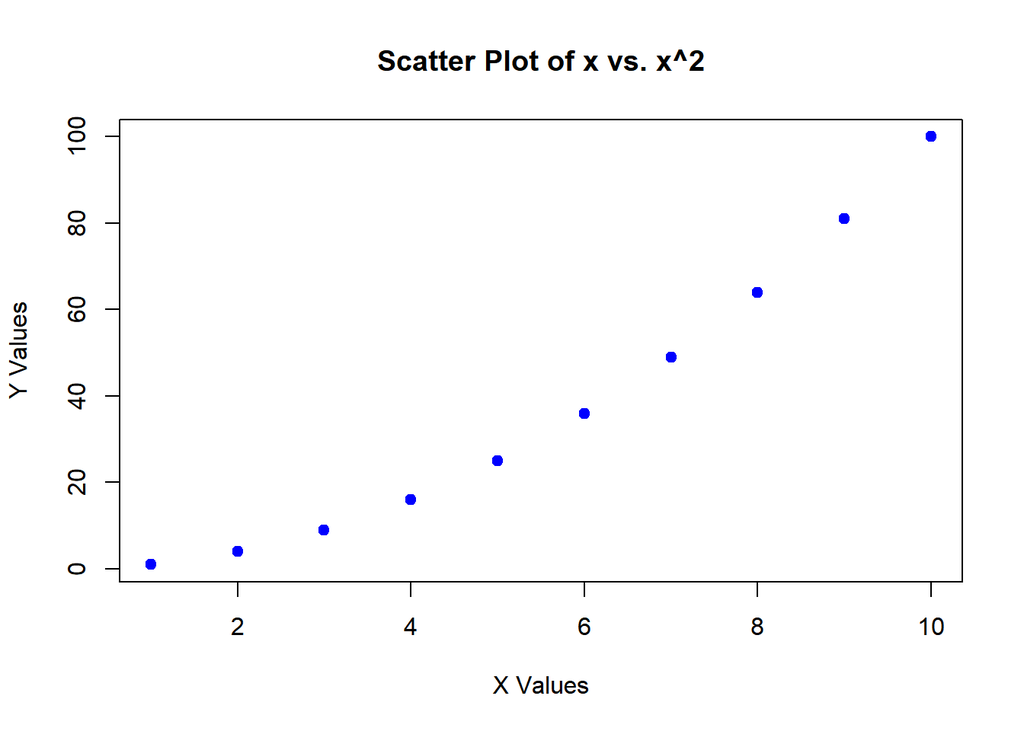

```r
# Generate sample data
x <- 1:10
y <- x^2

# Create a scatter plot
plot(x, y,
     main = "Scatter Plot of x vs. x^2",
     xlab = "X Values",
     ylab = "Y Values",
     pch = 19,      # pch defines the plotting symbol (19 is a solid circle)
     col = "blue")  # Set the color of the points
```

Example: Adding a Line

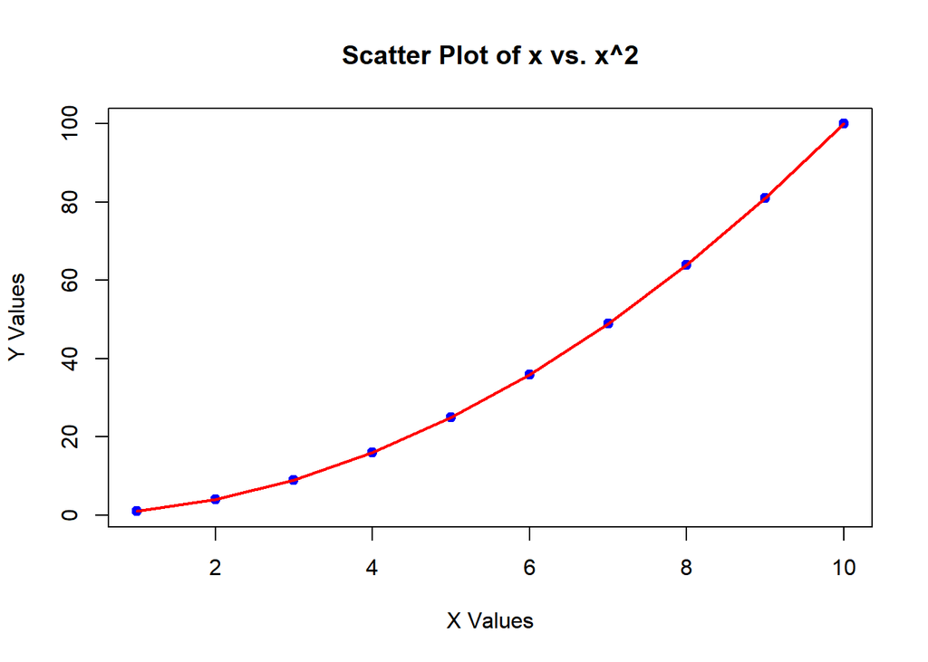

```r
plot(x, y,
     main = "Scatter Plot of x vs. x^2",
     xlab = "X Values",
     ylab = "Y Values",
     pch = 19,      # pch defines the plotting symbol (19 is a solid circle)
     col = "blue")  # Set the color of the points

# After creating the plot call:
# Add a line connecting the points
lines(x, y, col = "red", lwd = 2)  # lwd sets the line width
```

## 3.2 Histograms

The hist() function is used to create histograms which show the distribution of a numerical variable.

Histograms are used to display the distribution of a continuous variable. They break the data into bins and show how many values fall into each bin. This type of plot is ideal for understanding the underlying distribution (e.g., normal, skewed, bimodal) of your data.

Example: Histogram

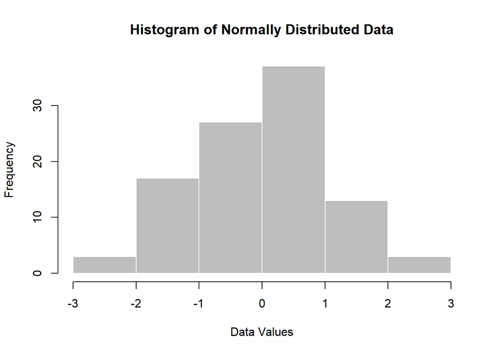

```r
# Generate random data from a normal distribution
data <- rnorm(100)

# Create a histogram
hist(data,
     main = "Histogram of Normally Distributed Data",
     xlab = "Data Values",
     col = "gray",
     border = "white")
```

## 3.3 Boxplots

Boxplots provide a summary of the distribution of data through its quartiles and are excellent for comparing distributions between groups. They show the median, the interquartile range, and potential outliers.

Example: Boxplot

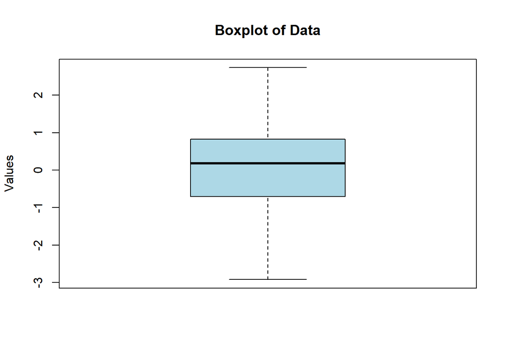

```r
# Create a boxplot for the generated data
boxplot(data,
        main = "Boxplot of Data",
        ylab = "Values",
        col = "lightblue")
```

## 3.4 Barplots

Barplots are useful for categorical data. They display the frequency or value associated with each category, making it easy to compare different groups or categories side by side. The barplot() function creates bar charts to display the frequency of categories.

Example: Barplot

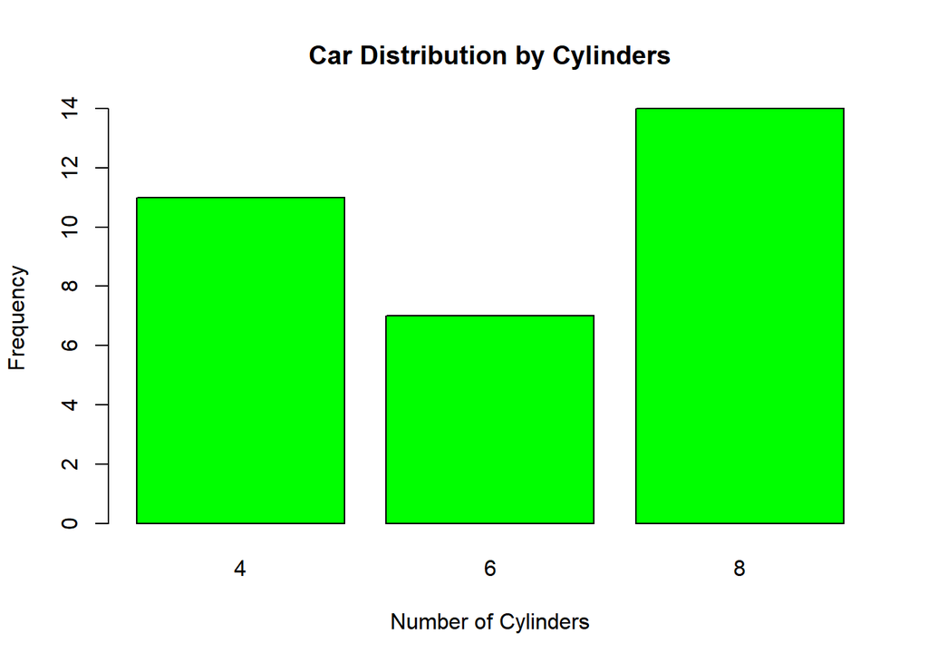

```r
# Using the built-in mtcars dataset to create a barplot
# Count the frequency of cars with different numbers of cylinders
cylinder_counts <- table(mtcars$cyl)

# Create a barplot
barplot(cylinder_counts,
        main = "Car Distribution by Cylinders",
        xlab = "Number of Cylinders",
        ylab = "Frequency",
        col = "green")
```

# 4. Customizing Your Plots

R’s base graphics functions offer many options to tweak your plots:

- Titles and Labels: Use main, xlab, and ylab to add a main title and axis labels.
- Colors: Change colors with the col parameter.
- Symbols and Lines: Adjust point symbols with pch and line styles with lty (line type).
- Legends: Add legends using the legend() function to help explain plot elements.

Example: Adding a Legend

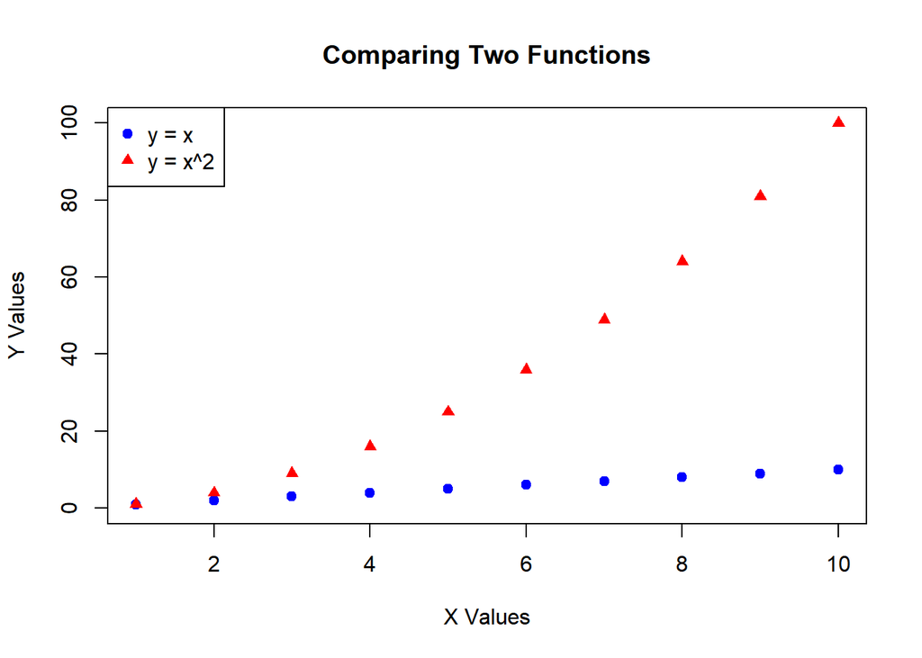

```r
# Create a scatter plot with two sets of points
x <- 1:10
y1 <- x
y2 <- x^2

plot(x, y1,
     main = "Comparing Two Functions",
     xlab = "X Values",
     ylab = "Y Values",
     pch = 19,
     col = "blue",
     ylim = c(0, 100))

points(x, y2,
       pch = 17,    # different symbol for second set
       col = "red")

# Add a legend to distinguish the two sets of points
legend("topleft",
       legend = c("y = x", "y = x^2"),
       col = c("blue", "red"),
       pch = c(19, 17))
```

# 5. Combining and Enhancing Plots

### 5.1 Multiple Plots in One Window:

Use par(mfrow=c(nrows, ncols)) to divide the plotting window into a matrix of plots. Example:

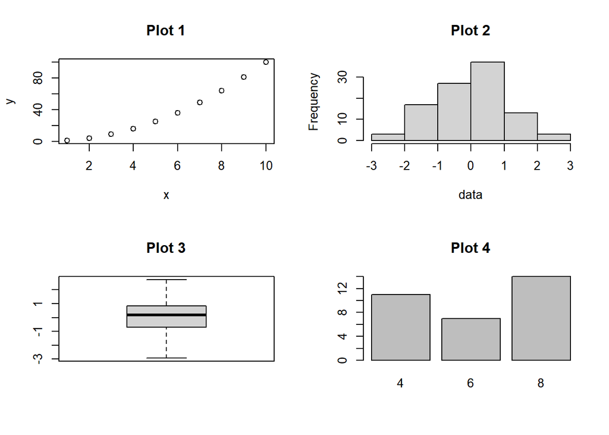

```r
par(mfrow = c(2, 2))  # Create a 2x2 grid of plots
plot(x, y, main = "Plot 1")
hist(data, main = "Plot 2")
boxplot(data, main = "Plot 3")
barplot(cylinder_counts, main = "Plot 4")
```

```r
par(mfrow = c(1, 1))  # Reset to a single plot layout
```

### 5.2 Example 1: Adding Extra Points and Overlaying Lines

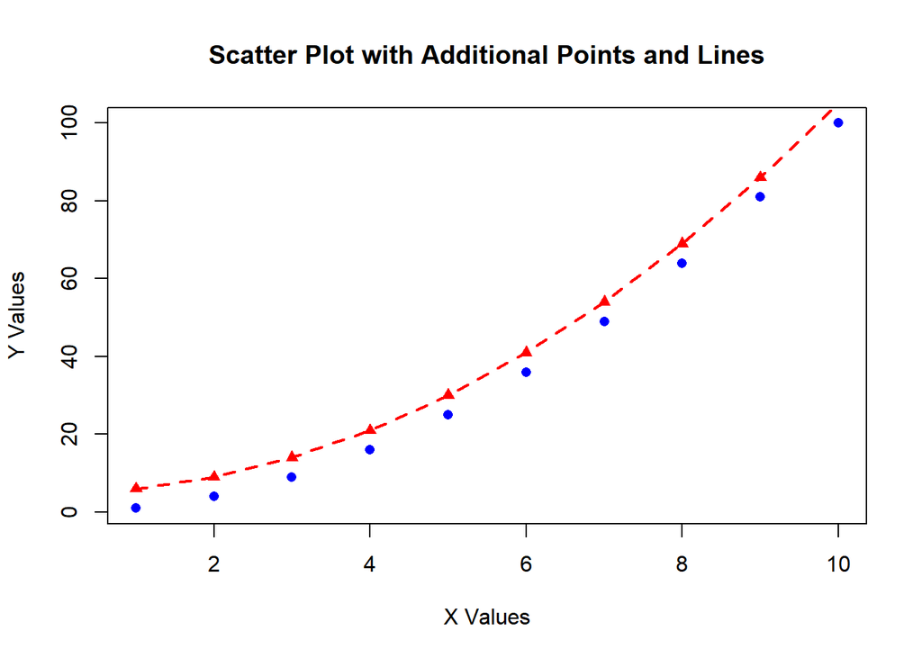

```r
# Generate a sequence for the x-axis
x <- 1:10

# Calculate y as a quadratic function (y = x^2)
y <- x^2

# Create a basic scatter plot
plot(x, y,
     main = "Scatter Plot with Additional Points and Lines",
     xlab = "X Values",
     ylab = "Y Values",
     pch = 16,         # Solid circle for data points
     col = "blue")     # Blue color for the primary data points

# Suppose we have additional data points showing a slightly different trend, e.g., y = x^2 + 5
y_extra <- x^2 + 5

# Add these extra data points to the existing plot
points(x, y_extra,
       col = "red",    # Red color to distinguish from the original data
       pch = 17)       # Different plotting symbol (triangle) for clarity

# Overlay a dashed line to connect the new data points, making the trend more visible
lines(x, y_extra,
      col = "red",    # Matching red color for consistency
      lwd = 2,        # Increase line width for better visibility
      lty = 2)        # Dashed line type
```

### 5.3 Example 2: Adding Annotations

Use text() or mtext() to add annotations or additional text.

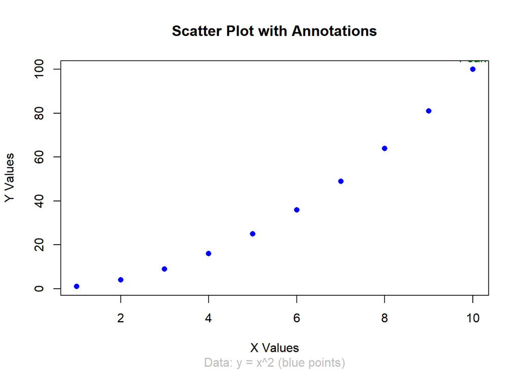

```r
# Generate a sequence for x and calculate the corresponding y values
x <- 1:10
y <- x^2

# Create a scatter plot of the data
plot(x, y,
     main = "Scatter Plot with Annotations",
     xlab = "X Values",
     ylab = "Y Values",
     pch = 16,
     col = "blue")

# Identify the maximum value (peak) in y and its corresponding x value
max_index <- which.max(y)

# Use text() to annotate the peak point directly on the plot
text(x[max_index], y[max_index],
     labels = "Peak",      # The label to display
     pos = 3,              # Position the text above the point (1=below, 2=left, 3=above, 4=right)
     col = "darkgreen")    # Color for the annotation

# Use mtext() to add descriptive text in the margin of the plot
mtext("Data: y = x^2 (blue points)",
      side = 1,           # 1 = bottom margin
      line = 4,           # Number of lines out from the plot
      col = "gray")       # Color for the margin text
```

# 6. Plotting with Multiple Groups

Most of the time, we want to go beyond ‘univariate’ plots (where we only represent the distribution of one variable) or even bivariate plots like the scatter plot above (showing an association between x and y). Additionally, we might want to consider a grouping variable. Common cases include comparisons between treatment and control group, men and women, democracies and non-democracies.

## 6.1 Scatter Plot with Multiple Groups

Using the built-in iris dataset, we can compare two quantitative variables (Sepal Length and Sepal Width) and distinguish between species using different colors and symbols.

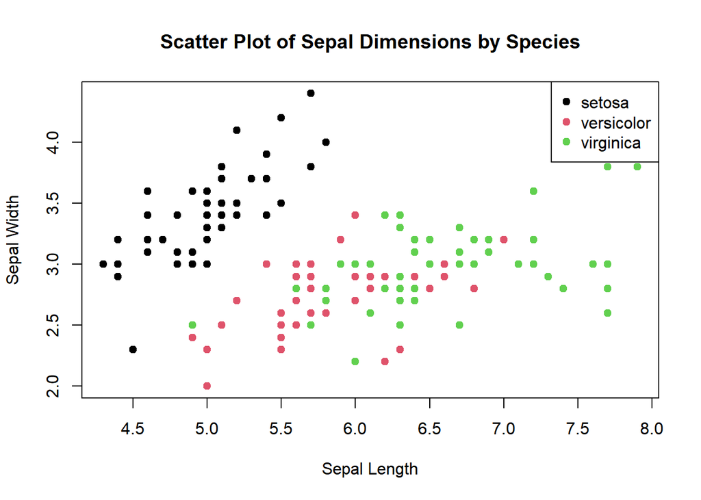

```r
# Load the iris dataset (already available in R)
data(iris)

# Create a scatter plot of Sepal Length vs. Sepal Width
plot(iris$Sepal.Length, iris$Sepal.Width,
     main = "Scatter Plot of Sepal Dimensions by Species",
     xlab = "Sepal Length",
     ylab = "Sepal Width",
     pch = 19,                                # Solid circle for each point
     col = as.numeric(iris$Species))          # Different colors based on species

# Add a legend mapping colors to species
legend("topright",
       legend = levels(iris$Species),
       col = 1:length(levels(iris$Species)),
       pch = 19)
```

## 6.2 Boxplot with Multiple Groups

We can use the same dataset to represent the variation in the measure for sepal length across species. Note the use of the `~` symbol. This is called a “tilde” and symbolizes the concept of “by”. In this example, we are asking R to plot the distribution of `Sepal.Length` “by” `Species`.

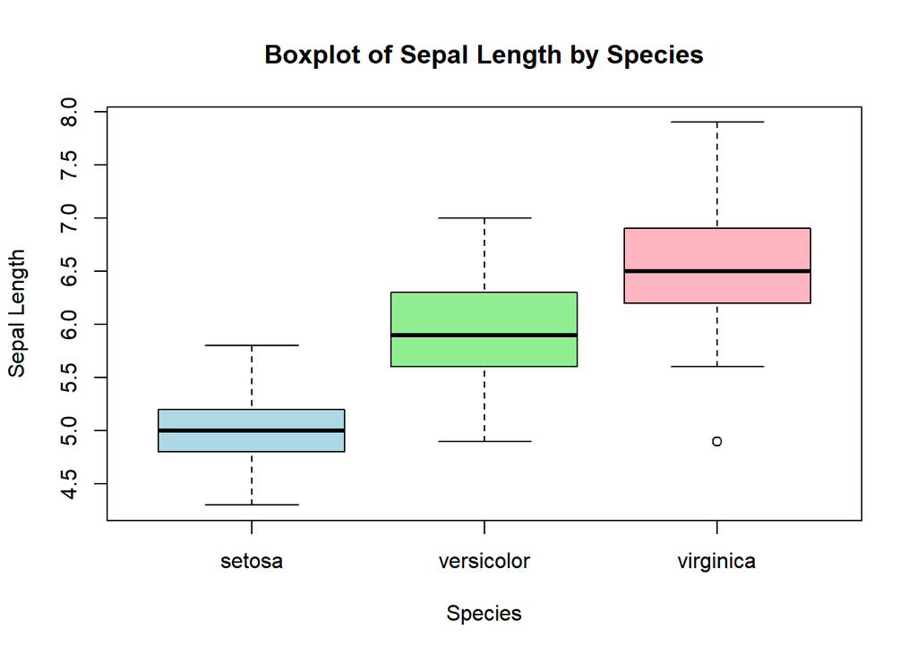

```r
# Create a boxplot of Sepal Length for each Species in the iris dataset
boxplot(Sepal.Length ~ Species, data = iris,
        main = "Boxplot of Sepal Length by Species",
        xlab = "Species",
        ylab = "Sepal Length",
        col = c("lightblue", "lightgreen", "lightpink"))
```

## 6.3 Barplot wiht Multiple Groups

Using the mtcars dataset, we can compare the distribution of car gears for different cylinder groups. A grouped (or side-by-side) barplot helps to compare counts across two categorical variables.

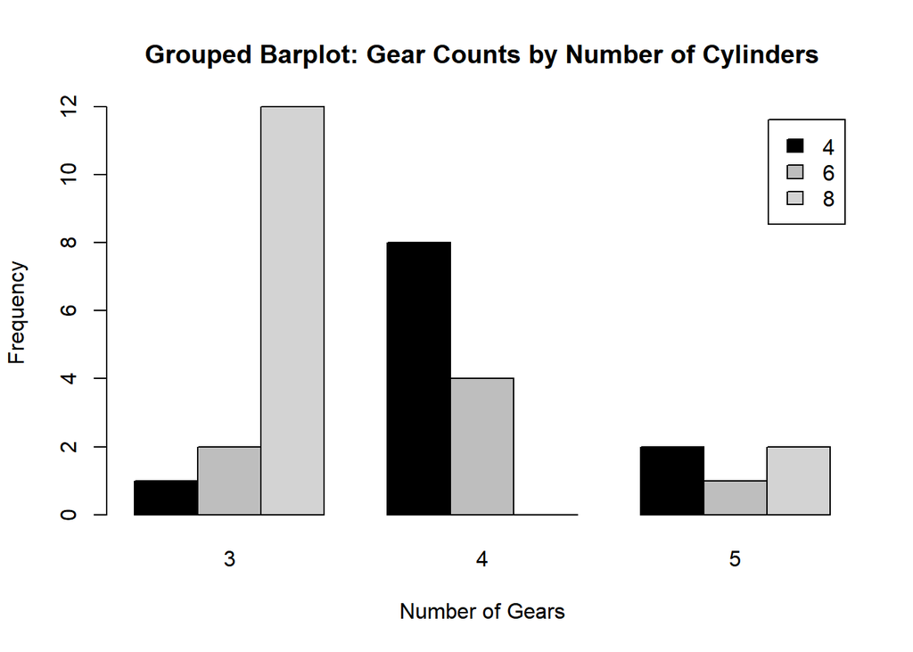

```r
# Create a contingency table of cylinders vs. gears from the mtcars dataset
counts <- table(mtcars$cyl, mtcars$gear)

# Create a grouped barplot (beside = TRUE) to display counts for each gear within cylinder groups
barplot(counts,
        beside = TRUE,
        col = c("black", "grey", "lightgrey"),
        legend = rownames(counts),
        main = "Grouped Barplot: Gear Counts by Number of Cylinders",
        xlab = "Number of Gears",
        ylab = "Frequency")
```

# 7. Saving Your Plots

After creating a plot, you can save it to a file using graphic devices such as png(), jpeg(), or pdf(). Begin by calling the function `png` and then supplying the dimensions and name of the image to be saved, create the plot, and conclude creating the export by calling `dev.off`.

Example: Saving a Plot as a PNG

```r
# Open a PNG device
png("my_scatter_plot.png", width = 800, height = 600)

# Create the plot
plot(x, y,
     main = "Saved Scatter Plot",
     xlab = "X Values",
     ylab = "Y Values",
     pch = 19,
     col = "blue")
lines(x, y, col = "red", lwd = 2)

# Close the device to save the file
dev.off()
```

# 8. Conclusion

This guide covers the basics of using R’s base graphics system for data visualization. Practice these functions with your own data, experiment with different parameters, and explore further customization to create compelling plots. As you become more comfortable, you might want to explore advanced plotting packages like ggplot2 for even more powerful visualizations.

Happy plotting!